# Restaurant Inspections

## 1. Introduction

In this data analysis project, I will try to use data on restaurant inspections to predict the number of days until the next inspection.

- CAMIS: a unique identifier for the restaurant
- DBA: name of (doing business as) the restaurant
- BORO: borough in which the restaurant is located
- BUILDING: building number for the restaurant
- STREET: street name at which the restaurant is located
- ZIPCODE: Zip code as per the (mailing) address of the restaurant
- PHONE: phone number
- CUISINE DESCRIPTION: cuisine of the restaurant
- INSPECTION DATE: date of inspection
- ACTION: action associated with the given inspection
- VIOLATION CODE: violation code associated with the given inspection
- VIOLATION DESCRIPTION: description that corresponds to violation code
- CRITICAL FLAG: indication if violation is critical or not
- SCORE: total score for a particular inspection
- GRADE: grade issued for the given inspection
- GRADE DATE: date when the current grade was issued to the restaurant
- RECORD DATE: The date when the extract was run to produce this data set
- INSPECTION TYPE: The type of inspection. A combination of the program and inspection type

We read in the data:

```r
(restaurants_raw <- read_excel("New_York_City_Restaurants.xlsx"))
```

| CAMIS | DBA | BORO | BUILDING | STREET | ZIPCODE | PHONE | CUISINE DESCRIPTION | INSPECTION DATE | ACTION | VIOLATION CODE | VIOLATION DESCRIPTION | CRITICAL FLAG | SCORE | GRADE | GRADE DATE | RECORD DATE | INSPECTION TYPE |
| --- | --- | --- | --- | --- | --- | --- | --- | --- | --- | --- | --- | --- | --- | --- | --- | --- | --- |
| 50018098 | EDEN WOK | MANHATTAN | 43 | E 34TH ST | 10016 | 2127258100 | Jewish/Kosher | 2015-01-29 | Violations were cited in the following area(s). | 04N | Filth flies or food/refuse/sewage-associated (FRSA) flies present in facility\032s food and/or non-food areas. Filth flies include house flies, little house flies, blow flies, bottle flies and flesh f… | Critical | 18 | B | 2015-01-29 | 2018-03-21 | Pre-permit (Operational) / Re-inspection |
| 40867812 | RUBENS PIZZERIA-EL POLLO PERUVIAN CUISINE | BROOKLYN | 1533 | 70 STREET | 11228 | 7183318821 | Pizza | 2015-11-23 | Violations were cited in the following area(s). | 20D | Choking first aid\032 poster not posted. \032Alcohol and pregnancy\032 warning sign not posted. Resuscitation equipment: exhaled air resuscitation masks (adult & pediatric), latex gloves, sign not pos… | Not Critical | NA | NA |  | 2018-03-21 | Administrative Miscellaneous / Initial Inspection |
| 50061071 | KUNGFU KITCHEN 805 | MANHATTAN | 805 | 8TH AVE | 10019 | 6468526941 | Chinese | 2017-04-11 | Violations were cited in the following area(s). | 10B | Plumbing not properly installed or maintained; anti-siphonage or backflow prevention device not provided where required; equipment or floor not properly drained; sewage disposal system in disrepair or… | Not Critical | 11 | NA |  | 2018-03-21 | Pre-permit (Operational) / Initial Inspection |
| 50045348 | MCDONALD'S | MANHATTAN | 1499 | 3RD AVE | 10028 | 2126288100 | American | 2017-06-28 | Violations were cited in the following area(s). | 02B | Hot food item not held at or above 140Âº F. | Critical | 9 | A | 2017-06-28 | 2018-03-21 | Cycle Inspection / Re-inspection |
| 50066056 | Brooklyn Wing House | BROOKLYN | 1218 | UNION ST | 11225 | 7182594647 | American | 2017-11-21 | Violations were cited in the following area(s). | 10F | Non-food contact surface improperly constructed. Unacceptable material used. Non-food contact surface or equipment improperly maintained and/or not properly sealed, raised, spaced or movable to allow … | Not Critical | 3 | A | 2017-11-21 | 2018-03-21 | Pre-permit (Operational) / Re-inspection |
| 41552594 | ASELLINA RISTORANTE | MANHATTAN | 420 | PARK AVENUE SOUTH | 10016 | 2123172908 | Italian | 2015-12-14 | Violations were cited in the following area(s). | 06E | Sanitized equipment or utensil, including in-use food dispensing utensil, improperly used or stored. | Critical | 12 | NA |  | 2018-03-21 | Cycle Inspection / Initial Inspection |
| 50037301 | TACO Y BURRITO [EL ANCLA PUERTO PLATA] | MANHATTAN | 142 | NAGLE AVE | 10040 | 2125675557 | Latin (Cuban, Dominican, Puerto Rican, South & Central American) | 2016-08-08 | Violations were cited in the following area(s). | 04A | Food Protection Certificate not held by supervisor of food operations. | Critical | 31 | C | 2016-08-08 | 2018-03-21 | Cycle Inspection / Re-inspection |
| 41230776 | KAM SHING CHINESE RESTAURANT | BROOKLYN | 1608 | AVENUE H | 11230 | 7184215252 | Chinese | 2017-03-04 | Violations were cited in the following area(s). | 22A | Nuisance created or allowed to exist. Facility not free from unsafe, hazardous, offensive or annoying conditions. | Not Critical | NA | NA |  | 2018-03-21 | Administrative Miscellaneous / Re-inspection |
| 41705979 | NEPALESE INDIAN RESTAURANT | QUEENS | 907 | SENECA AVENUE | 11385 | 7184171873 | Indian | 2016-10-06 | Violations were cited in the following area(s). | 04L | Evidence of mice or live mice present in facility's food and/or non-food areas. | Critical | 15 | NA |  | 2018-03-21 | Cycle Inspection / Initial Inspection |
| 41360136 | BUTTERFIELD CATERING | MANHATTAN | 346 | EAST 92 STREET | 10128 | 2127728782 | American | 2016-06-29 | Violations were cited in the following area(s). | 06D | Food contact surface not properly washed, rinsed and sanitized after each use and following any activity when contamination may have occurred. | Critical | 10 | A | 2016-06-29 | 2018-03-21 | Cycle Inspection / Re-inspection |

[output cut: 990 more lines]

For convenience, we rename the variables.

```r
new_names <- c("id", "rest_name", "boro", "building", "street", "zipcode",
               "phone", "cuisine_descr", "inspection_date", "action",
               "violation_code", "violation_descr", "critical_flag",
               "score", "grade", "grade_date", "record_date",
               "inspection_type")
(names(restaurants_raw) <- new_names)
```

```
 [1] "id"              "rest_name"       "boro"            "building"
 [5] "street"          "zipcode"         "phone"           "cuisine_descr"
 [9] "inspection_date" "action"          "violation_code"  "violation_descr"
[13] "critical_flag"   "score"           "grade"           "grade_date"
[17] "record_date"     "inspection_type"
```

```r
rm(new_names)
```

## 2. Exploratory Analysis

Let us turn to the exploration of the data..

### 2.1 Inspection Date

```r
restaurants_raw$inspection_date <- ymd(restaurants_raw$inspection_date)
summary(restaurants_raw$inspection_date)
```

```
        Min.      1st Qu.       Median         Mean      3rd Qu.         Max.
"1900-01-01" "2015-09-09" "2016-08-10" "2016-03-26" "2017-07-18" "2018-03-19"
```

Apparently, there are some obeservations with an inspection date of “1900-01-01”. Of course, these are wrong values. Let us look at these observations, in particular at the variables that relate to the grade of an inspection.

```r
restaurants_raw %>%
  filter(inspection_date == "1900-01-01") %>%
  select(action:inspection_type)
```

| action | violation_code | violation_descr | critical_flag | score | grade | grade_date | record_date | inspection_type |
| --- | --- | --- | --- | --- | --- | --- | --- | --- |
| NA | NA | NA | Not Applicable | NA | NA |  | 2018-03-21 | NA |
| NA | NA | NA | Not Applicable | NA | NA |  | 2018-03-21 | NA |
| NA | NA | NA | Not Applicable | NA | NA |  | 2018-03-21 | NA |
| NA | NA | NA | Not Applicable | NA | NA |  | 2018-03-21 | NA |
| NA | NA | NA | Not Applicable | NA | NA |  | 2018-03-21 | NA |
| NA | NA | NA | Not Applicable | NA | NA |  | 2018-03-21 | NA |
| NA | NA | NA | Not Applicable | NA | NA |  | 2018-03-21 | NA |
| NA | NA | NA | Not Applicable | NA | NA |  | 2018-03-21 | NA |
| NA | NA | NA | Not Applicable | NA | NA |  | 2018-03-21 | NA |
| NA | NA | NA | Not Applicable | NA | NA |  | 2018-03-21 | NA |

[output cut: 990 more lines]

Values of all observations across all the variables relating to grading are missing.

```r
restaurants_raw %>%
  summarise(na_inspectionDate = round((sum(inspection_date == "1900-01-01")/n()), 4))
```

| na_inspectionDate |
| --- |
| 0.0031 |

```r
restaurants_raw <- restaurants_raw %>%
  filter(!inspection_date == "1900-01-01")
```

### 2.2 Boros

Next, let us take a look at the distribution of ‘Boro’.

```r
restaurants_raw$boro <- as.factor(restaurants_raw$boro)
levels(restaurants_raw$boro)[levels(restaurants_raw$boro) == "Missing"] <- NA
summary(restaurants_raw$boro)
```

```
        BRONX      BROOKLYN     MANHATTAN        QUEENS STATEN ISLAND
        33105         94772        149821         85191         12900
```

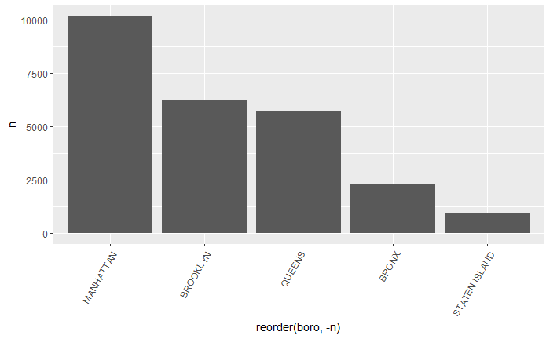

```r
restaurants_raw %>%
  group_by(boro) %>%
  summarize(n = n_distinct(id)) %>%
  ggplot(aes(x = reorder(boro, -n), y = n)) +
  geom_bar(stat = "identity") +
  theme(axis.text.x = element_text(angle=60, hjust=1))
```

Most observations are from Manhattan.

### 2.3 Actions taken

```r
levels(as.factor(restaurants_raw$action))
```

```
[1] "Establishment Closed by DOHMH.  Violations were cited in the following area(s) and those requiring immediate action were addressed."
[2] "Establishment re-closed by DOHMH"
[3] "Establishment re-opened by DOHMH"
[4] "No violations were recorded at the time of this inspection."
[5] "Violations were cited in the following area(s)."
```

We convert it into a factor and (re)name its levels for convenience:

```r
restaurants_raw$action <- as.factor(restaurants_raw$action)
levels(restaurants_raw$action) <- c("Closed", "ReClosed", "ReOpened", "NoViol", "YesViol")
summary(restaurants_raw$action)
```

```
  Closed ReClosed ReOpened   NoViol  YesViol
   10145     1116     2973     4898   356657
```

```r
(action_df <- restaurants_raw %>%
  group_by(action) %>%
  summarise(n = n()) %>%
  arrange(desc(n)))
```

| action | n |
| --- | --- |
| YesViol | 356657 |
| Closed | 10145 |
| NoViol | 4898 |
| ReOpened | 2973 |
| ReClosed | 1116 |

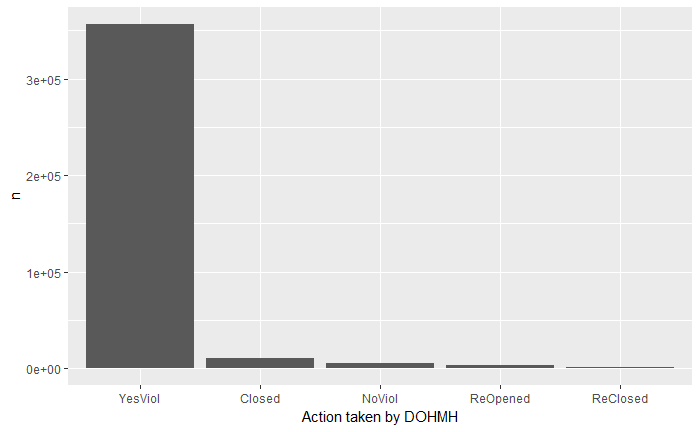

```r
action_df %>%
  ggplot(aes(reorder(action, -n), n)) +
  geom_bar(stat = "identity") +
  xlab("Action taken by DOHMH")
```

In the vast majority of inspections violations were cited. Among these, a very small number leads to restaurant closures.

### 2.7 Violation types

Next, we will consider the different types of violations recorded.

```r
restaurants_raw$violation_code <- as.factor(restaurants_raw$violation_code)
restaurants_raw %>%
  group_by(violation_code) %>%
  summarise(number = n()) %>%
  mutate(rank = rank(desc(number))) %>%
  filter(rank <= 10) %>%
  arrange(rank)
```

| violation_code | number | rank |
| --- | --- | --- |
| 10F | 53154 | 1 |
| 08A | 38706 | 2 |
| 04L | 26768 | 3 |
| 06C | 25521 | 4 |
| 06D | 25215 | 5 |
| 02G | 23866 | 6 |
| 10B | 21819 | 7 |
| 02B | 19023 | 8 |
| 04N | 18882 | 9 |
| 04H | 8174 | 10 |

10F (general violation pertaining to non-food contact surfaces) is the most common violation type. followed by 08A (facility not vermin proof), 04L (Evidence of mice).

Here is a quick plot of the distribution:

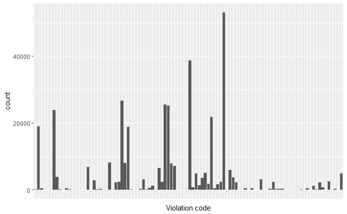

```r
restaurants_raw %>%
  ggplot(aes(x = violation_code)) +
  geom_bar() +
  theme(axis.text.x = element_blank(),
        axis.ticks.x = element_blank()) +
  xlab("Violation code")
```

To get a better sense of what is going on, we group the values in the range of violation_code into broader categories. To do this, we use information from the provided by the authorities. Accordingly, violations are either scored or unscored. Among scored violations, we have to distinguish between critical and general violations.

```r
violations <- restaurants_raw$violation_code
patterns <- list(
  violations %in% str_c("02", LETTERS[1:10]) ~ "crit_food_temperature",
  violations %in% str_c("03", LETTERS[1:7]) ~ "crit_food_source",
  violations %in% str_c("04", LETTERS[1:15]) ~ "crit_food_protection",
  violations %in% str_c("05", LETTERS[1:9]) ~ "crit_facility_design",
  violations %in% str_c("06", LETTERS[1:9]) ~ "crit_personal_hygiene",
  violations == "07A" ~ "crit_other",
  violations %in% str_c("08", LETTERS[1:3]) ~ "gen_vermin",
  violations %in% str_c("09", LETTERS[1:3]) ~ "gen_food_source",
  violations %in% str_c("10", LETTERS[1:10]) ~ "gen_facility_manage",
  violations == "99B" ~ "gen_other",
  !is.na(violations) ~ "not_scored"
  )
# New variable violation_group:
restaurants_raw <-
  restaurants_raw %>%
  mutate(violation_group = case_when(!!!patterns))
rm(patterns)
rm(violations)
```

Here is bar plot displaying the distribution

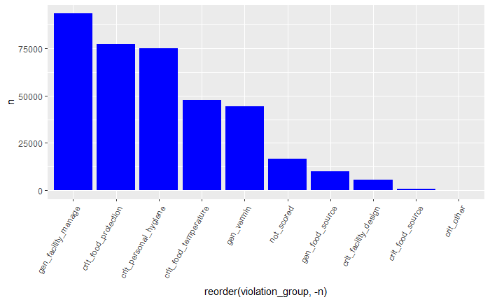

```r
restaurants_raw %>%
  group_by(violation_group) %>%
  filter(!is.na(violation_group)) %>%
  summarize(n = n()) %>%
  ggplot(aes(reorder(violation_group, -n), n)) +
  geom_bar(stat = "identity", fill = "blue") +
  theme(axis.text.x = element_text(angle=60, hjust=1))
```

Some categories barely contain any observations. For the time being, we will keep the chosen binning. We are going to revisit this point in the context of feature engineering.

Here is the distribution of violation code again. This time we incorporate the variable violation group.

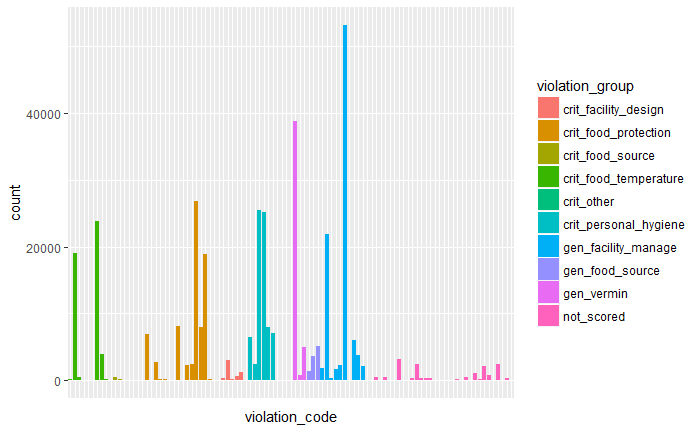

```r
restaurants_raw %>%
  filter(!is.na(violation_group)) %>%
  ggplot(aes(x = violation_code, fill = violation_group)) +
  geom_bar() +
  theme(axis.text.x = element_blank(),
        axis.ticks.x = element_blank())
```

### 2.8 Inspection types

The variable inspection type takes on 34 distinct values:

```r
restaurants_raw %>%
     summarise(n_distinct(inspection_type))
```

| n_distinct(inspection_type) |
| --- |
| 34 |

These are the values:

```r
restaurants_raw %>%
  group_by(inspection_type) %>%
  summarise()
```

| inspection_type |
| --- |
| Administrative Miscellaneous / Compliance Inspection |
| Administrative Miscellaneous / Initial Inspection |
| Administrative Miscellaneous / Re-inspection |
| Administrative Miscellaneous / Reopening Inspection |
| Administrative Miscellaneous / Second Compliance Inspection |
| Calorie Posting / Compliance Inspection |
| Calorie Posting / Initial Inspection |
| Calorie Posting / Re-inspection |
| Calorie Posting / Second Compliance Inspection |
| Cycle Inspection / Compliance Inspection |

[output cut: 24 more lines]

We collapse these values into a smaller range:

```r
restaurants_raw$inspection_type2 <-  restaurants_raw %>%
  select(inspection_type) %>%
  separate(inspection_type, into = c("before_slash", "after_slash"), sep = " / ") %>%
  transmute(after_slash = str_replace_all(after_slash, fixed(" "), fixed(""))) %>%
  transmute(inspection_type2 = str_replace_all(after_slash, fixed("-i"), fixed("I"))) %>%
  .$inspection_type2
unique(restaurants_raw$inspection_type2)
```

```
[1] "ReInspection"               "InitialInspection"          "ComplianceInspection"
[4] "ReopeningInspection"        "SecondComplianceInspection" "LimitedInspection"
```

Here a display of the distribution:

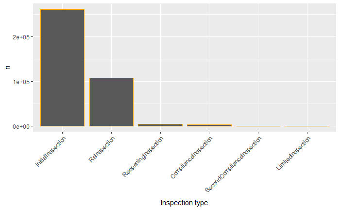

```r
restaurants_raw %>%
  group_by(inspection_type2) %>%
  summarise(n = n()) %>%
  ggplot(aes(reorder(as.factor(inspection_type2), -n), n)) +
  geom_bar(stat = "identity", color = "orange") +
  xlab("Inspection type") +
  theme(axis.text.x = element_text(angle = 45, hjust = 1))
```

Again, there a are categories that are ‘almost empty’. The vast majority of observations are initial and re-inspections:

```r
restaurants_raw %>%
  group_by(inspection_type2) %>%
  summarise(n = n(), prop = round(n/nrow(restaurants_raw), 5)) %>%
  arrange(desc(n))
```

| inspection_type2 | n | prop |
| --- | --- | --- |
| InitialInspection | 261126 | 0.69487 |
| ReInspection | 107536 | 0.28616 |
| ReopeningInspection | 4388 | 0.01168 |
| ComplianceInspection | 2601 | 0.00692 |
| SecondComplianceInspection | 134 | 0.00036 |
| LimitedInspection | 4 | 0.00001 |

For later purposes, we contruct a dummy variable for the category ‘InitialInspection’.

```r
restaurants_raw$dummy_InitialInspection <-
  ifelse(restaurants_raw$inspection_type2 == "InitialInspection", 1, 0)
names(restaurants_raw)
```

```
 [1] "id"                      "rest_name"               "boro"
 [4] "building"                "street"                  "zipcode"
 [7] "phone"                   "cuisine_descr"           "inspection_date"
[10] "action"                  "violation_code"          "violation_descr"
[13] "critical_flag"           "score"                   "grade"
[16] "grade_date"              "record_date"             "inspection_type"
[19] "violation_group"         "inspection_type2"        "dummy_InitialInspection"
```

### 2.9 Grade

```r
restaurants_raw %>%
  group_by(grade) %>%
  summarise(n = n()) %>%
  arrange(desc(n))
```

| grade | n |
| --- | --- |
| NA | 187702 |
| A | 149897 |
| B | 24696 |
| C | 6318 |
| Z | 3510 |
| Not Yet Graded | 1915 |
| P | 1751 |

There is a massive amount of NA’s. We are going to investigate how the number of NAs for ‘grade’ relates to ‘score’ and ‘inspection_type.’ More precisely, we know that on initial inspections no grade is issued, if the corresponding score is above 14. It seems plausible that this would lead to a value of NA for grade.

```r
restaurants_raw %>%
  select(inspection_type2, score, grade) %>%
  filter(inspection_type2 == "InitialInspection", score > 14) %>%
  group_by(grade) %>%
  summarise(n = n())
```

| grade | n |
| --- | --- |
| Not Yet Graded | 1548 |
| NA | 137410 |

So about 73 % of the missing values are due to a score of 14 or higher. Furthermore, out of the 1915 observations with value ‘Not yet graded’, 1548 are the result of a high score (above 13) in the initial inspection. We will recode these NA’s to “Not Yet Graded” to reduce the number of missing values for ‘grade’.

```r
# Recode NA's with inspection type = 'InitialInspection' and 'score' > 14 to "Not Yet Graded":
restaurants_raw <- restaurants_raw %>%
  mutate(grade = case_when(
    is.na(.$grade) &
      .$inspection_type2 == "InitialInspection" &
      .$score > 14 ~ "Not Yet Graded",
    TRUE ~ grade
  ))
```

We have reduced the number of NA’s significantly:

```r
restaurants_raw %>%
  summarise(prop_na = round(mean(is.na(grade)), 2),
            n_not_graded = sum(grade == "Not Yet Graded", na.rm = T))
```

| prop_na | n_not_graded |
| --- | --- |
| 0.13 | 139325 |

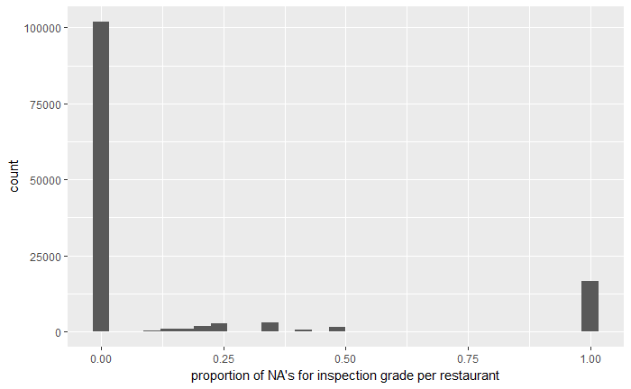

```r
restaurants_raw %>%
  group_by(id, inspection_date) %>%
  summarise(prop_gradeNA = mean(is.na(grade))) %>%
  ggplot(aes(x = prop_gradeNA)) +
  geom_histogram(bins = 30) +
  xlab("proportion of NA's for inspection grade per restaurant")
```

```r
restaurants_raw %>%
  group_by(id, inspection_date) %>%
  summarise(prop_gradeNA = round(mean(is.na(grade)), 3)) %>%
  ungroup() %>%
  group_by(prop_gradeNA) %>%
  summarise(proportion_of_restaurants = round(n()/nrow(.), 3)) %>%
  arrange(desc(proportion_of_restaurants))
```

| prop_gradeNA | proportion_of_restaurants |
| --- | --- |
| 0.000 | 0.781 |
| 1.000 | 0.128 |
| 0.333 | 0.024 |
| 0.250 | 0.020 |
| 0.200 | 0.012 |
| 0.500 | 0.011 |
| 0.167 | 0.008 |
| 0.143 | 0.004 |
| 0.400 | 0.003 |
| 0.125 | 0.002 |

[output cut: 29 more lines]

As we did before, we are going to construct dummy variables, this time for the different levels of grade. We’ll use “Z” as base category:

```r
temp_index <- restaurants_raw$grade == "Not Yet Graded"
restaurants_raw$grade[temp_index] <- "NotYetGraded"
rm(temp_index)
for(level in unique(restaurants_raw$grade)){

  if (is.na(level) | level == "Z") {
    next
  } else {
    restaurants_raw[paste("dummy", level, sep = "_")] <-
      ifelse(!is.na(restaurants_raw$grade) &
               restaurants_raw$grade == level, 1, 0)
  }

}
rm(level)
names(restaurants_raw)
```

```
 [1] "id"                      "rest_name"               "boro"
 [4] "building"                "street"                  "zipcode"
 [7] "phone"                   "cuisine_descr"           "inspection_date"
[10] "action"                  "violation_code"          "violation_descr"
[13] "critical_flag"           "score"                   "grade"
[16] "grade_date"              "record_date"             "inspection_type"
[19] "violation_group"         "inspection_type2"        "dummy_InitialInspection"
[22] "dummy_B"                 "dummy_A"                 "dummy_C"
[25] "dummy_NotYetGraded"      "dummy_P"
```

### 2.10 Score

Let us turn to ‘score’.

```r
summary(restaurants_raw$score)
```

```
   Min. 1st Qu.  Median    Mean 3rd Qu.    Max.    NA's
  -2.00   11.00   14.00   18.93   24.00  151.00   19514
```

There are 19514 NA’s. We know that there are 16530 observations that refer to violations that are not scored:

```r
restaurants_raw %>%
  group_by(violation_group) %>%
  summarise(n = n()) %>%
  filter(violation_group == "not_scored")
```

| violation_group | n |
| --- | --- |
| not_scored | 16530 |

These observations are expected to have NA for ‘score’:

```r
restaurants_raw %>%
  select(violation_group, score) %>%
  filter(violation_group == "not_scored") %>%
  summarise(n = n(), n_na_score = sum(is.na(score)), prop_na_score = round(n_na_score/n, 2))
```

| n | n_na_score | prop_na_score |
| --- | --- | --- |
| 16530 | 16086 | 0.97 |

Hence, these observations account for 82 % of all of the 19514 NA’s for ‘score’. We will recode them to have a score of 0:

```r
# Recode score NA's for which violation group is 'not_scored' to 0:
restaurants_raw$score[restaurants_raw$violation_group == "not_scored"] <- 0
# Remaining NA's:
sum(is.na(restaurants_raw$score))
```

```
[1] 3428
```

What about these remaining 3428 missing values for ‘score’? Let us consider the relationship with violation group:

```r
restaurants_raw %>%
  select(violation_group, score) %>%
  filter(is.na(violation_group)) %>%
  summarise(n = n(), n_na_score = sum(is.na(score)))
```

| n | n_na_score |
| --- | --- |
| 4921 | 3428 |

Hence, the rest of the NA’s for score are associated with NA’s on ‘violation_group’. So let us turn to the NA’s for the variable ‘violation_group’. One cause for an NA here may be that on a given inspection, there was no violation at all. So what is the number of NA’s for score among observations that do not exhibit a violation?

```r
restaurants_raw %>% filter(action == "NoViol") %>%
  summarise(scoreNAs_among_noViolation = sum(is.na(score)))
```

| scoreNAs_among_noViolation |
| --- |
| 3426 |

Apparently, almost all of 3428, namely 3426, can be assumed to be the result of a non-violation. So now, there are only 2 missing values for score left. We’ll assign them the median value of the non-Na scores:

```r
restaurants_raw$score[is.na(restaurants_raw$score)] <-
  median(restaurants_raw$score[!is.na(restaurants_raw$score)])
sum(is.na(restaurants_raw$score))
```

```
[1] 0
```

## 3. Predicting the number of days until the next inspection

### 3.1 Split into training and test data

```r
set.seed(1)
train_ids <- sample(unique(restaurants_raw$id), 0.6*length(unique(restaurants_raw$id)))
test_ids <- setdiff(unique(restaurants_raw$id), train_ids)
```

Next, let us see if the distributions of the target feature in training and test data are similar:

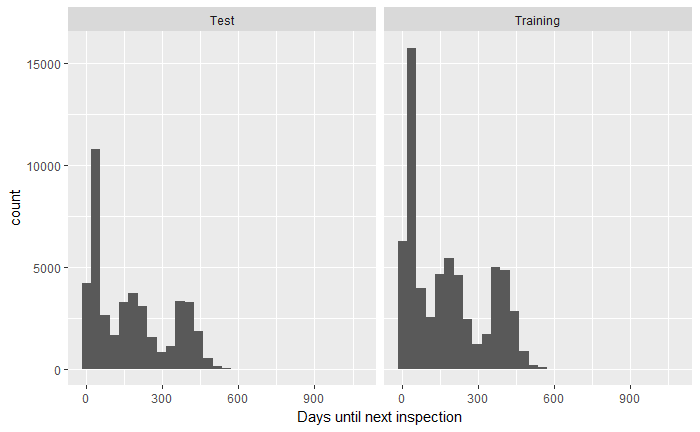

```r
restaurants_raw %>%
  select(id, inspection_date) %>%
  group_by(id, inspection_date) %>%
  arrange(inspection_date) %>%
  summarise() %>%
  mutate(difference = lead(inspection_date) - inspection_date) %>%
  filter(!is.na(difference)) %>%
  mutate(group = ifelse(id %in% train_ids, "Training", "Test")) %>%
  ggplot(aes(as.numeric(difference))) +
  geom_histogram(bins = 30) +
  xlab("Days until next inspection") +
  facet_grid(. ~ group)
```

The distribution of the target seems reasonably similar across training and test data. Now, we’ll split the data set into training and test data:

```r
# Training data
train_df <- restaurants_raw %>%
  filter(id %in% train_ids)
# Test data
test_df <- restaurants_raw %>%
  filter(id %in% test_ids)
```

So now, we remove the original data set and test data from the workspace and save the latter to a file:

```r
write.csv(test_df, "test_restaurants.csv")
rm(restaurants_raw)
rm(test_df)
```

### 3.2

```r
train_df %>%
  select(id, inspection_date, inspection_type2, score, grade,
         dummy_A, dummy_B, dummy_C, dummy_NotYetGraded, dummy_P, dummy_Z) %>%
  group_by(id, inspection_date) %>%
  arrange(id, inspection_date) %>%
  summarise_at(c("grade", "score", "inspection_type2",
                 "dummy_A", "dummy_B", "dummy_C",
                 "dummy_NotYetGraded", "dummy_P", "dummy_Z"),
               .funs = list(first)) %>%
  mutate(days_until_next = lead(inspection_date) - inspection_date)
```

[output not shown]

[output cut: 990 more lines]